# Внешний курс. Блок 1. Безопасность в сети

Основы информационной безопасности

Краснова К. Г., НКАбд-03-24

Российский университет дружбы народов, Москва, Россия

17 февраля 2026

## Цель работы

Выполнение контрольных заданий первого блока внешнего курса “Основы Кибербезопасности”

# Выполнение заданий блока “Основы Кибербезопасности”

## Как работает интернет: базовые сетевые протоколы

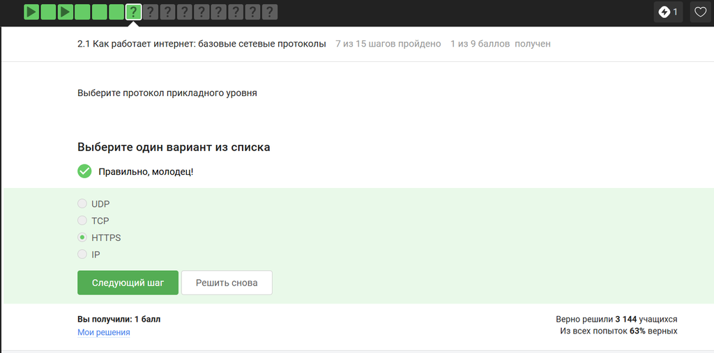

Вопрос 2.1.1

## Как работает интернет: базовые сетевые протоколы

Ранее было упомянуто, что протокол TCP - transmission control protocol - работает на транспортном уровне (рис. [-@fig:002]).

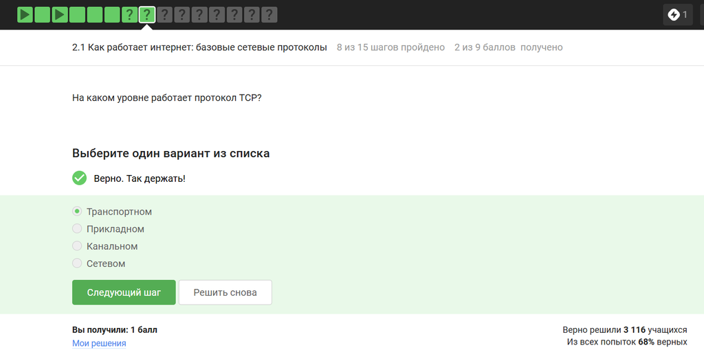

Вопрос 2.1.2

## Как работает интернет: базовые сетевые протоколы

В адресе типа IPv4 не может быть чисел больше 255, поэтому первые два варианта не подходят (рис. [-@fig:003]).

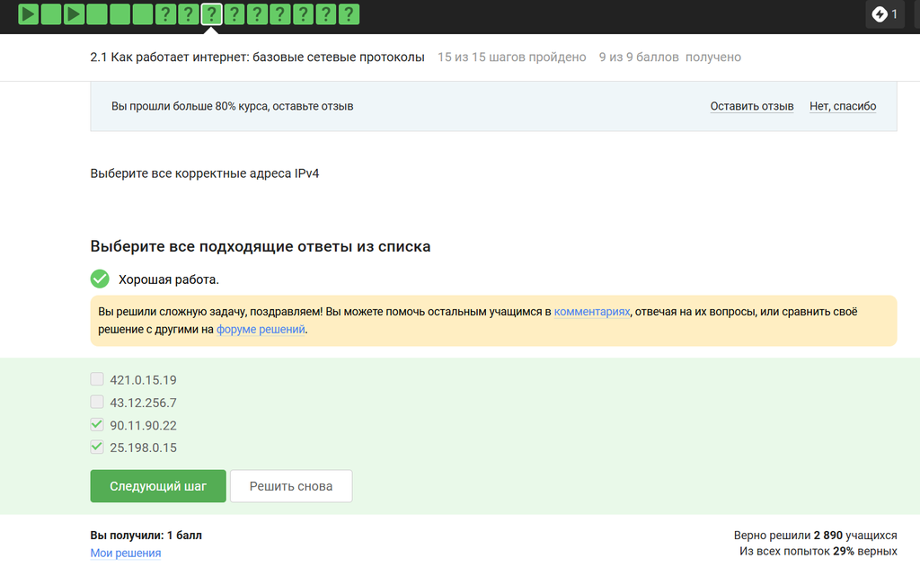

Вопрос 2.1.3

## Как работает интернет: базовые сетевые протоколы

DNS-сервер, Domain name server — приложение, предназначенное для ответов на DNS-запросы по соответствующему протоколу Обязательное условие – Сопоставление сервером доменных имен доменного имени с IP-адресом называется разрешением имени и адреса (рис. [-@fig:004]).

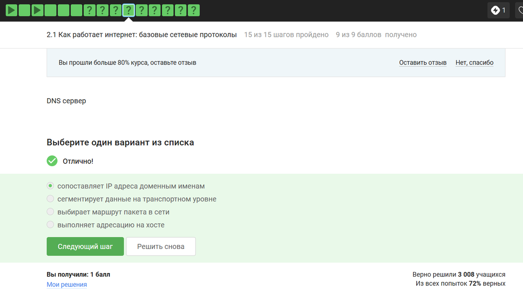

Вопрос 2.1.4

## Как работает интернет: базовые сетевые протоколы

Распределение протоколов в модели TCP/IP:

- Прикладной уровень (Application Layer): HTTP, RTSP, FTP, DNS.
- Транспортный уровень (Transport Layer): TCP, UDP, SCTP, DCCP.
- Сетевой (Межсетевой) уровень (Network Layer): IP.
- Уровень сетевого доступа (Канальный) (Link Layer): Ethernet, IEEE 802.11, WLAN, SLIP, Token Ring, ATM и MPLS. (рис. [-@fig:005]).

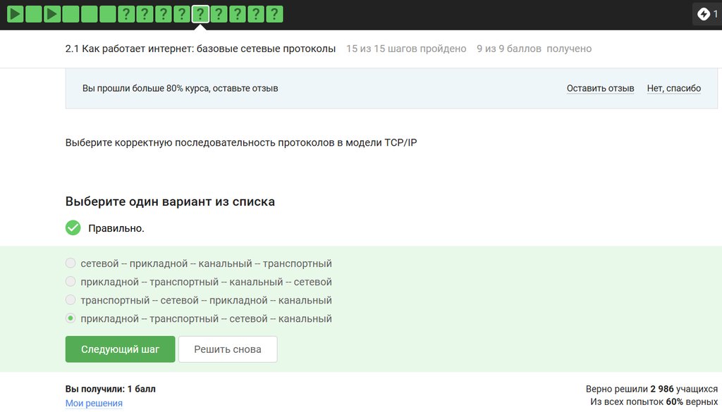

Вопрос 2.1.5

## Как работает интернет: базовые сетевые протоколы

Протокол http передает не зашифрованные данные, а протокол https уже будет передавать зашифрованные данные (рис. [-@fig:006]).

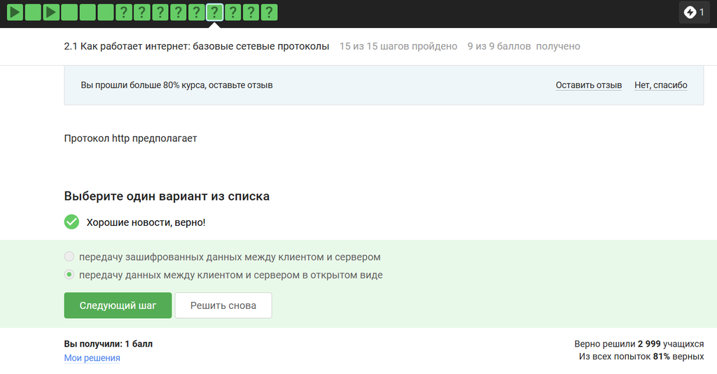

Вопрос 2.1.6

## Как работает интернет: базовые сетевые протоколы

https передает зашифрованные данные, одна из фаз - передача данных, другая должна быть рукопожатием (рис. [-@fig:007]).

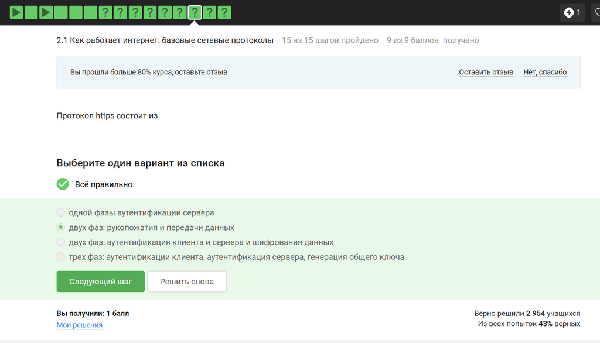

Вопрос 2.1.7

## Как работает интернет: базовые сетевые протоколы

TLS определяется и клиентом, и сервером, чтобы было возможно подключиться (рис. [-@fig:008]).

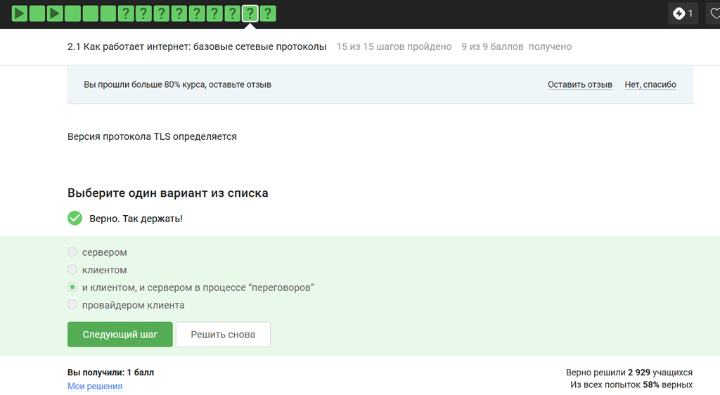

Вопрос 2.1.8

## Как работает интернет: базовые сетевые протоколы

Ответ на изобрадении, остальные варианты в протоколе предусмотрены (рис. [-@fig:009]).

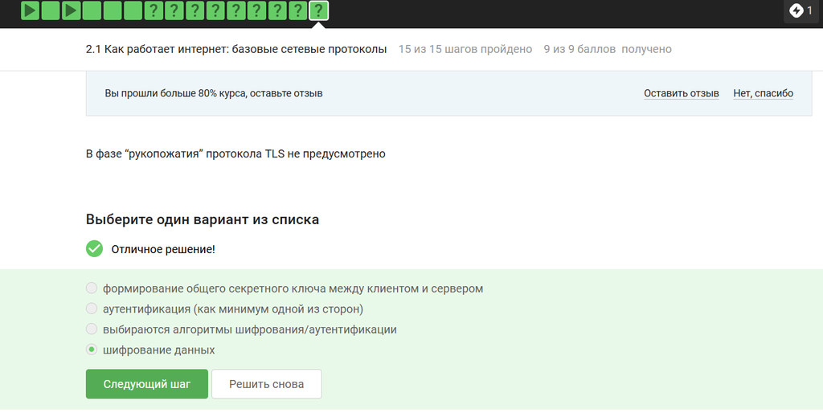

Вопрос 2.1.9

## Персонализация сети

Куки точно не хранят пароли и IP-адреса, а id ceccии и идентификатор хранят (рис. [-@fig:010]).

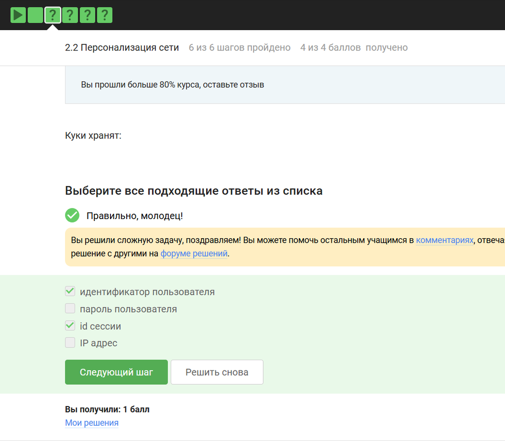

Вопрос 2.2.1

## Персонализация сети

Конечно же, куки не делают соединение более надежным (рис. [-@fig:011]).

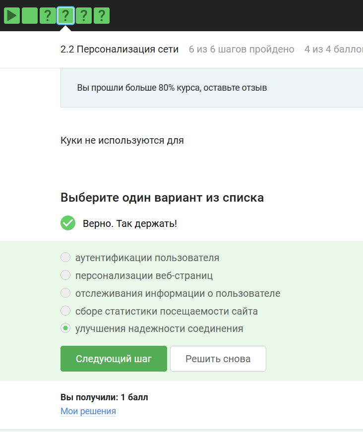

Вопрос 2.2.2

## Персонализация сети

Ответ на изображении (рис. [-@fig:012]).

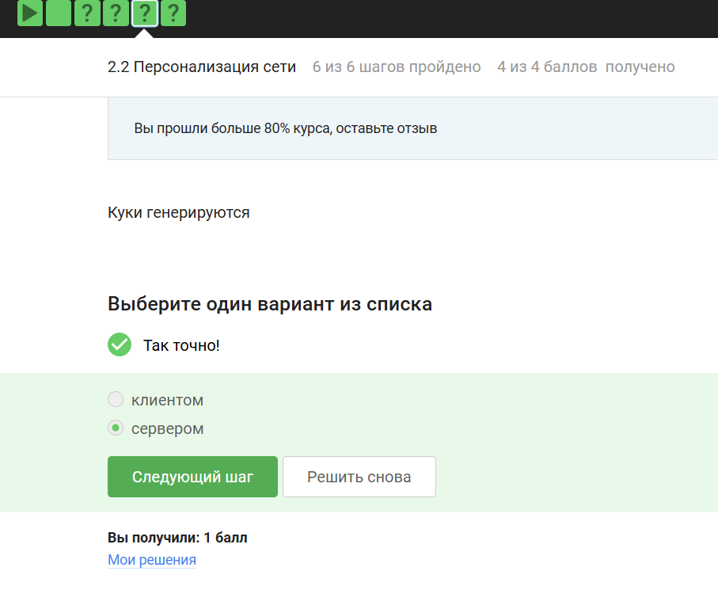

Вопрос 2.2.3

## Персонализация сети

Сессионные куки хранятся в течение сессии, то есть пока используется веб-сайт (рис. [-@fig:013]).

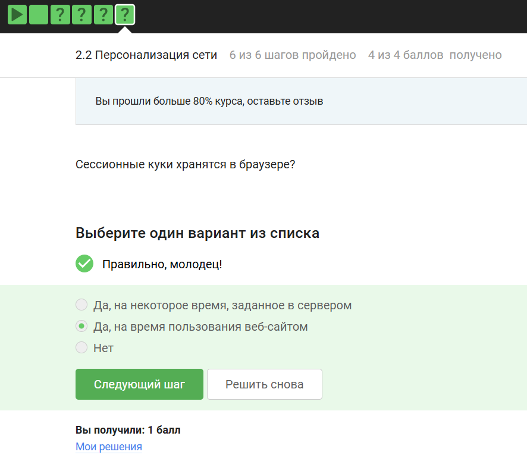

Вопрос 2.2.4

## Браузер TOR. Анонимизация

Необходимо три узла - входной, промежуточный и выходной (рис. [-@fig:014]).

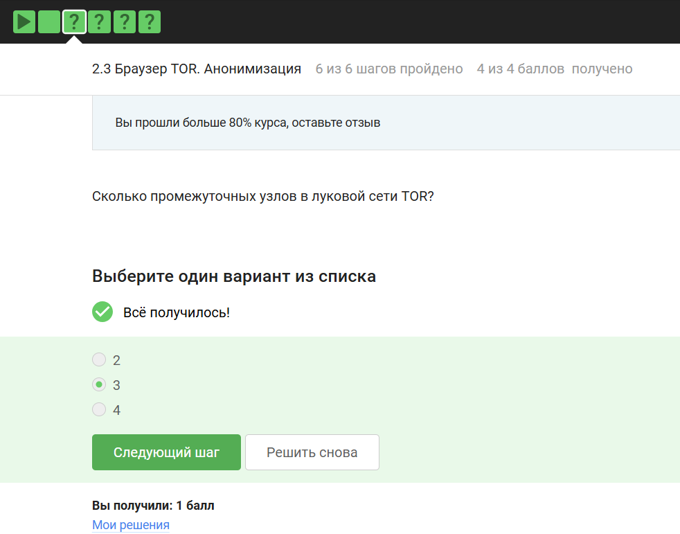

Вопрос 2.3.1

## Браузер TOR. Анонимизация

IP-адрес не должен быть известен охранному и промежуточному узлам (рис. [-@fig:015]).

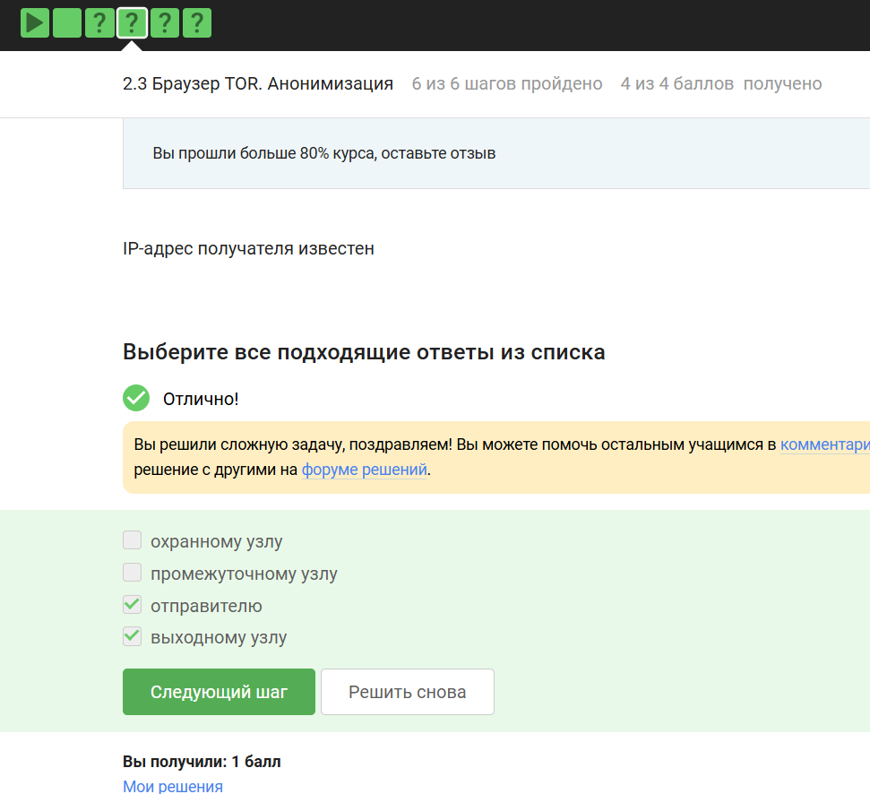

Вопрос 2.3.2

## Браузер TOR. Анонимизация

Отправитель генерирует общий секретный ключ со узлами, через которые идет передача, то есть со всеми (рис. [-@fig:016]).

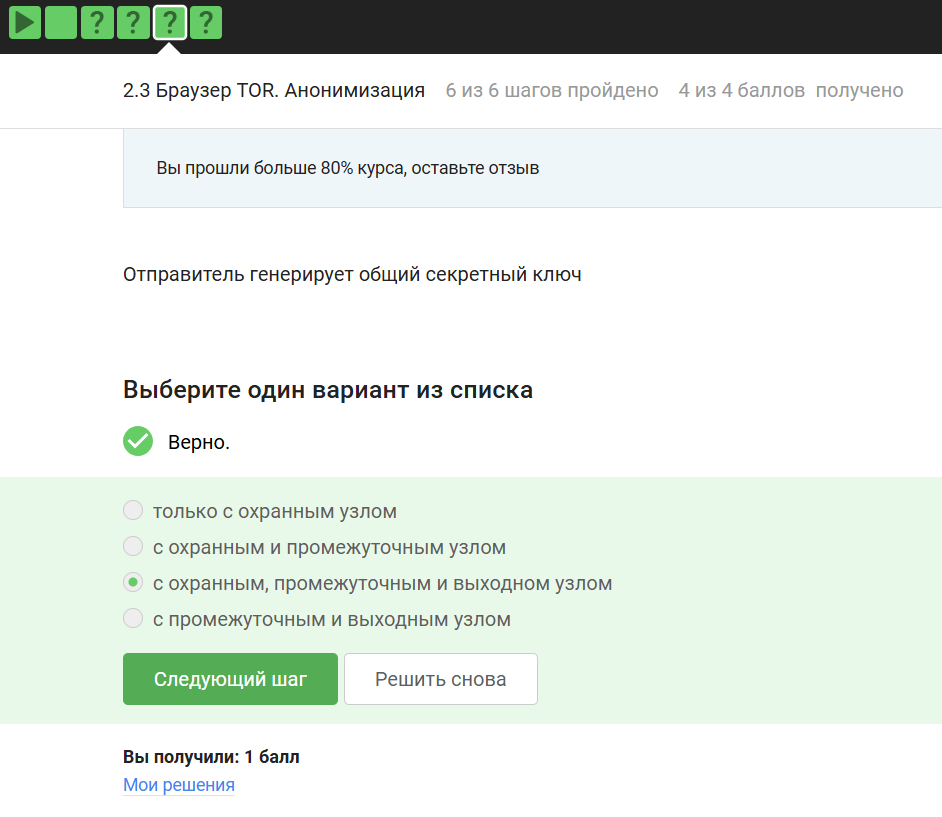

Вопрос 2.3.3

## Браузер TOR. Анонимизация

Для получаения пакетов не нужно использовать TOR. TOR — это технология, которая позволяет с некоторым успехом скрыть личность человека в интернете (рис. [-@fig:017]).

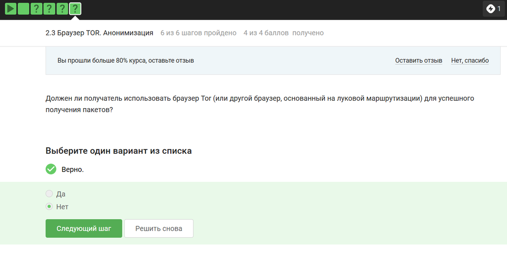

Вопрос 2.3.4

## Беспроводные сети Wi-fi

Действительно, это определение Wi-Fi (рис. [-@fig:018]).

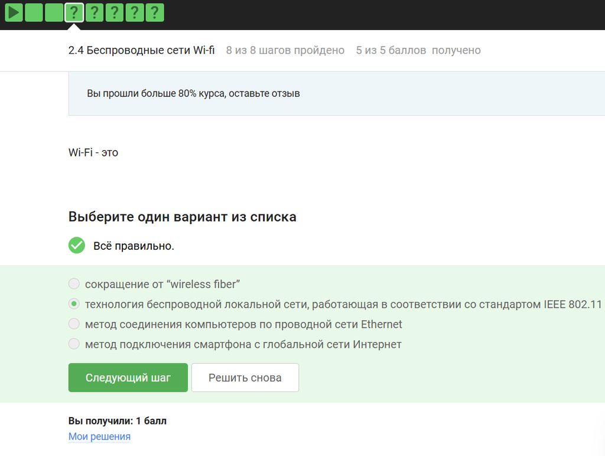

Вопрос 2.4.1

## Беспроводные сети Wi-fi

Для целей работы в Интернете Wi-Fi обычно располагается как канальный уровень (эквивалентный физическому и канальному уровням модели OSI) ниже интернет-уровня интернет-протокола. Это означает, что узлы имеют связанный интернет-адрес, и при подходящем подключении это обеспечивает полный доступ в Интернет. (рис. [-@fig:019]).

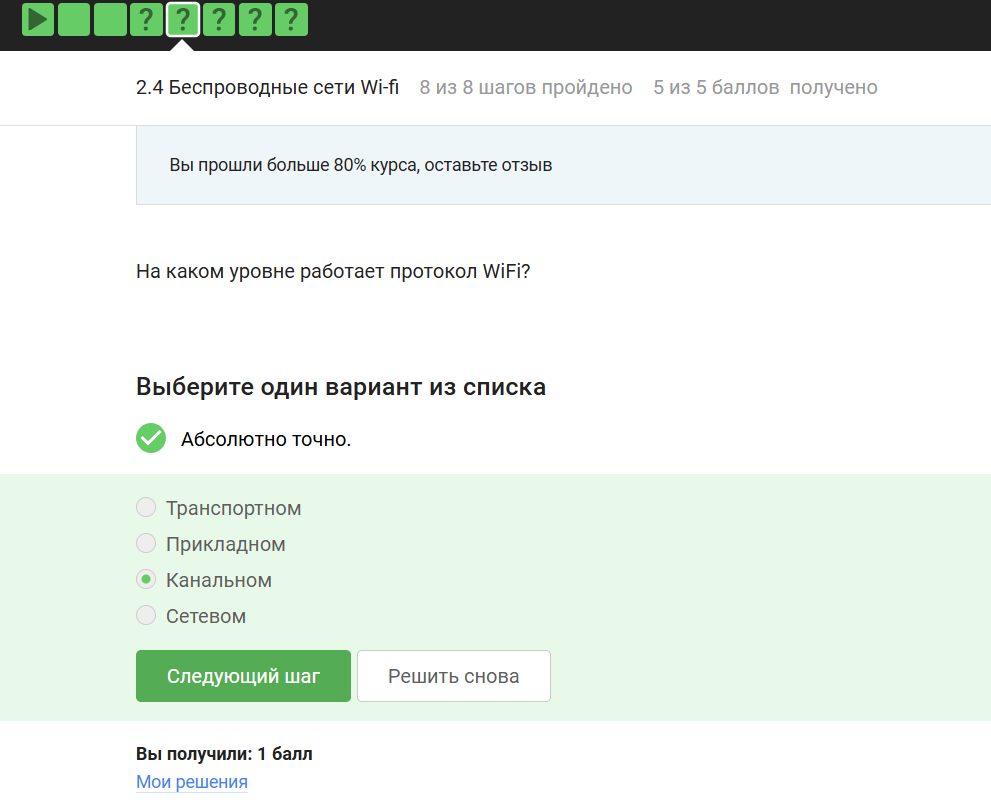

Вопрос 2.4.2

## Беспроводные сети Wi-fi

WEP (Wired Equivalent Privacy) – устаревший и небезопасный метод проверки подлинности. Это первый и не очень удачный метод защиты. Злоумышленники без проблем получают доступ к беспроводным сетям, которые защищены с помощью WEP, был заменен остальными представленными (рис. [-@fig:020]).

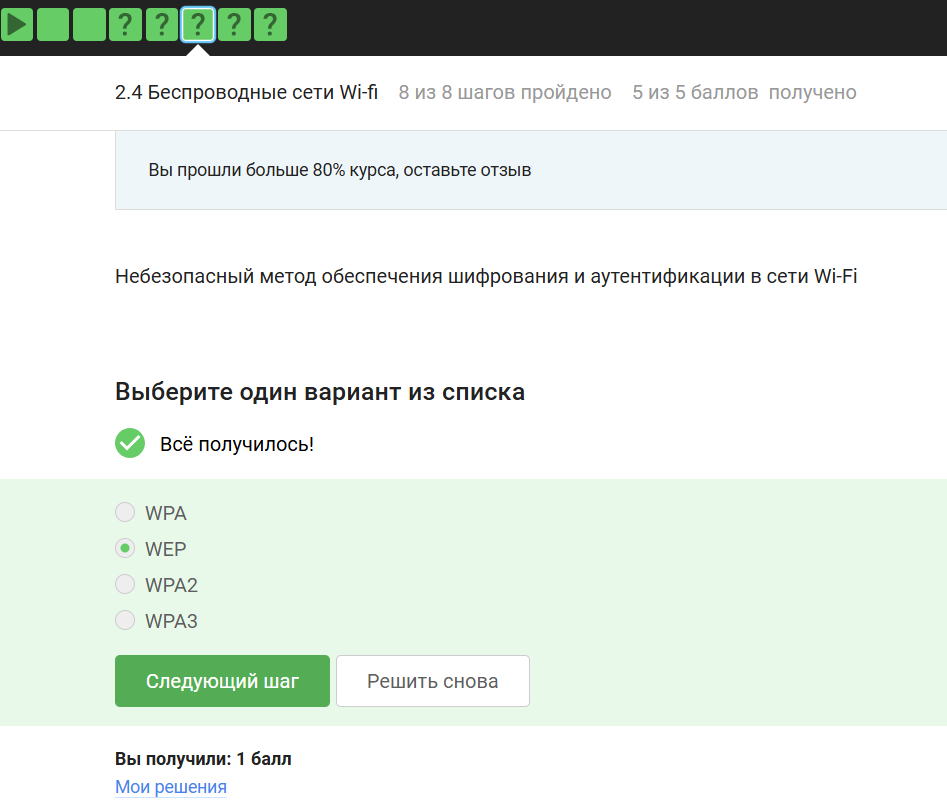

Вопрос 2.4.3

## Беспроводные сети Wi-fi

Нужно аутентифицировать устройства и позже передаются зашифрованные данные (рис. [-@fig:021]).

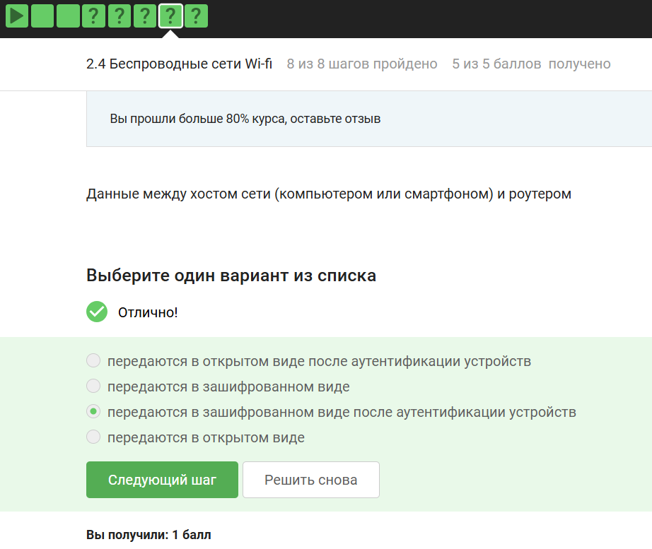

Вопрос 2.4.4

## Беспроводные сети Wi-fi

В целом, понятно по названию, что WPA2 Personal для личного использования, то есть для домашней сети, enterprise - для предпиятий (рис. [-@fig:022]).

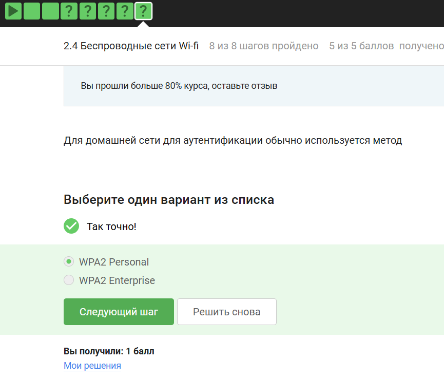

Вопрос 2.4.5

# Выводы

В ходе выполнения блока “Безопасность в сети” узнала о работе базовых сетевых протоколов, куки сетей Wi-Fi и браузера TOR.